# **Customer Segmentation Using RFM Analysis and K-Means Clustering**

## **Unsupervised Machine Learning for Customer Segmentation**

#### Author: Luis Rito Filipe

#### April, 2024

[figure not shown]

# Summary

This study presents a customer segmentation analysis using transactional data from the Online Retail II dataset. Following data preprocessing and exploratory data analysis, customer purchasing behavior was summarized through the Recency, Frequency, and Monetary (RFM) framework. After feature scaling, the optimal number of customer segments was determined using the Elbow Method, Silhouette Score, Calinski-Harabasz Index, and Davies-Bouldin Index. A K-Means clustering model identified four distinct customer segments, which were subsequently profiled and interpreted from a business perspective. Principal Component Analysis (PCA) was employed to visualize the resulting clusters in a two-dimensional feature space. Finally, business insights and marketing recommendations were proposed for each customer segment, illustrating how data-driven customer segmentation can support customer relationship management and targeted marketing strategies.

# About The Study

Understanding customer purchasing behavior is essential for retailers seeking to improve customer retention, optimize marketing campaigns, and allocate business resources more effectively. Rather than treating all customers equally, customer segmentation enables organizations to identify groups of customers with similar purchasing patterns and develop tailored strategies for each segment.

This study applies the widely adopted Recency-Frequency-Monetary (RFM) framework together with the K-Means clustering algorithm to identify meaningful customer segments from historical retail transactions. The analysis combines exploratory data analysis, feature engineering, unsupervised machine learning, and business interpretation to demonstrate a complete customer segmentation workflow.

# About The Dataset

The following study uses the Online Retail II dataset publicly available from UCI Machine Learning Repository (see link below), which contains transactional records from a UK-based online retailer between December 2009 and December 2011.

Dataset link: https://archive.ics.uci.edu/dataset/502/online+retail+ii

```python
import pandas as pd
import numpy as np
import calendar
import math
import matplotlib.pyplot as plt
import matplotlib.colors as mcolors
from matplotlib.colors import LinearSegmentedColormap, TwoSlopeNorm, Normalize
import matplotlib.gridspec as gridspec
from phik import phik_matrix
import seaborn as sns
from sklearn.preprocessing import StandardScaler, LabelEncoder
from sklearn.metrics import silhouette_score, calinski_harabasz_score, davies_bouldin_score
from sklearn.cluster import KMeans
from sklearn.calibration import calibration_curve
from sklearn.decomposition import PCA


pd.set_option('display.max_rows', None)
pd.set_option('display.max_columns', None)
pd.set_option('display.max_colwidth', None)
```

# Methodology

- Data Wrangling and Preprocessing
- Exploratory Data Analysis
- Feature Engineering
- Exploratory Analysis of RFM Features
- Feature Scaling
- Determining the Optimal Number of Clusters
- Model Training Using K-Means
- Cluster Analysis and Profiling
- Cluster Visualization Using Principal Component Analysis (PCA)
- Business Insights
- Business Recommendations
- Conclusions
- Future Work

# Data Wrangling and Preprocessing

Two datasets, each containing the same eight features, were loaded and concatenated into a single dataset for subsequent preprocessing and analysis. Each record corresponds to a product purchased within an invoice and includes information such as the invoice identifier, product description, purchased quantity, invoice date, unit price, customer identifier, and country. The summary statistics of the combined dataset are presented below.

```python
df1 = pd.read_csv("online_retail_II_1.csv")
df2 = pd.read_csv("online_retail_II_2.csv")
df = pd.concat([df1, df2], ignore_index=True).reset_index(drop=True)
df = df.rename(columns={"Customer ID" : "CustomerID"})
df.info(verbose=False)
df.describe(include="all")
```

```
<class 'pandas.core.frame.DataFrame'>
RangeIndex: 1067371 entries, 0 to 1067370
Columns: 8 entries, Invoice to Country
dtypes: float64(2), int64(1), object(5)
memory usage: 65.1+ MB
```

|  | Invoice | StockCode | Description | Quantity | InvoiceDate | Price | CustomerID | Country |
| --- | --- | --- | --- | --- | --- | --- | --- | --- |
| count | 1067371 | 1067371 | 1062989 | 1.067371e+06 | 1067371 | 1.067371e+06 | 824364.000000 | 1067371 |
| unique | 53628 | 5305 | 5698 | NaN | 47635 | NaN | NaN | 43 |
| top | 537434 | 85123A | WHITE HANGING HEART T-LIGHT HOLDER | NaN | 2010-12-06 16:57:00 | NaN | NaN | United Kingdom |
| freq | 1350 | 5829 | 5918 | NaN | 1350 | NaN | NaN | 981330 |
| mean | NaN | NaN | NaN | 9.938898e+00 | NaN | 4.649388e+00 | 15324.638504 | NaN |
| std | NaN | NaN | NaN | 1.727058e+02 | NaN | 1.235531e+02 | 1697.464450 | NaN |
| min | NaN | NaN | NaN | -8.099500e+04 | NaN | -5.359436e+04 | 12346.000000 | NaN |
| 25% | NaN | NaN | NaN | 1.000000e+00 | NaN | 1.250000e+00 | 13975.000000 | NaN |
| 50% | NaN | NaN | NaN | 3.000000e+00 | NaN | 2.100000e+00 | 15255.000000 | NaN |
| 75% | NaN | NaN | NaN | 1.000000e+01 | NaN | 4.150000e+00 | 16797.000000 | NaN |
| max | NaN | NaN | NaN | 8.099500e+04 | NaN | 3.897000e+04 | 18287.000000 | NaN |

The table below shows that the raw dataset contains approximately 243,000 transactions without a customer identifier and 4,382 transactions without a product description. Since customer segmentation relies on analyzing purchasing behavior at the individual customer level, records without a valid CustomerID cannot be associated with a specific customer and were therefore removed. Records with missing product descriptions were also excluded to ensure data completeness and consistency.

```python
df.isna().sum().reset_index(name="Count").rename(columns={"index": "Feature"}).style.hide(axis="index")
```

| Feature | Count |
| --- | --- |
| Invoice | 0 |
| StockCode | 0 |
| Description | 4382 |
| Quantity | 0 |
| InvoiceDate | 0 |
| Price | 0 |
| CustomerID | 243007 |
| Country | 0 |

The summary statistics indicate that the Invoice feature contains non-numeric values, which correspond to canceled transactions. Since these transactions do not represent completed purchases, they were removed from the dataset. Additionally, records with non-positive values in the Quantity and Price features were excluded, as they do not represent valid sales.

A new feature, TotalPrice, was created by multiplying Quantity by Price, representing the monetary value of each transaction. This feature is later used throughout the exploratory analysis and as the basis for the Monetary component of the RFM model.

Finally, the InvoiceDate feature was converted to the datetime data type to enable time-based analyses, while CustomerID was converted from float to integer after removing missing values, ensuring a more appropriate representation of customer identifiers.

```python
df = df.dropna(subset=["CustomerID"])
df = df[~df.index.isin(df.loc[pd.to_numeric(df["Invoice"], errors="coerce").isna(), "Invoice"].index)]
df = df[df["Quantity"] > 0]
df = df[df["Price"] > 0]
df["TotalPrice"] = df["Quantity"] * df["Price"]
df["InvoiceDate"] = pd.to_datetime(df["InvoiceDate"])
df["CustomerID"] = df["CustomerID"].astype(int)
df = df.reset_index(drop=True)
```

# Exploratory Data Analysis

After completing the preprocessing steps, the dataset contained only valid purchase transactions associated with identified customers, providing a reliable foundation for the subsequent exploratory analysis and customer segmentation. The summary statistics of the cleaned dataset are presented below.

```python
df.describe(include="all")
```

|  | Invoice | StockCode | Description | Quantity | InvoiceDate | Price | CustomerID | Country | TotalPrice |
| --- | --- | --- | --- | --- | --- | --- | --- | --- | --- |
| count | 805549 | 805549 | 805549 | 805549.000000 | 805549 | 805549.000000 | 805549.000000 | 805549 | 805549.000000 |
| unique | 36969 | 4631 | 5283 | NaN | NaN | NaN | NaN | 41 | NaN |
| top | 576339 | 85123A | WHITE HANGING HEART T-LIGHT HOLDER | NaN | NaN | NaN | NaN | United Kingdom | NaN |
| freq | 542 | 5188 | 5181 | NaN | NaN | NaN | NaN | 725250 | NaN |
| mean | NaN | NaN | NaN | 13.290522 | 2011-01-02 10:24:44.106814464 | 3.206561 | 15331.954970 | NaN | 22.026505 |
| min | NaN | NaN | NaN | 1.000000 | 2009-12-01 07:45:00 | 0.001000 | 12346.000000 | NaN | 0.001000 |
| 25% | NaN | NaN | NaN | 2.000000 | 2010-07-07 12:08:00 | 1.250000 | 13982.000000 | NaN | 4.950000 |
| 50% | NaN | NaN | NaN | 5.000000 | 2010-12-03 15:10:00 | 1.950000 | 15271.000000 | NaN | 11.850000 |
| 75% | NaN | NaN | NaN | 12.000000 | 2011-07-28 13:05:00 | 3.750000 | 16805.000000 | NaN | 19.500000 |
| max | NaN | NaN | NaN | 80995.000000 | 2011-12-09 12:50:00 | 10953.500000 | 18287.000000 | NaN | 168469.600000 |
| std | NaN | NaN | NaN | 143.634088 | NaN | 29.199173 | 1696.737039 | NaN | 224.041928 |

The distribution of transactions by country reveals that the United Kingdom overwhelmingly dominates the dataset, accounting for approximately 33,500 transactions. Germany, EIRE, and France follow with between 500 and 800 transactions each, representing only a small fraction of the total. This highly skewed distribution indicates that the retailer's business is primarily concentrated in the United Kingdom, while international markets contribute comparatively fewer transactions. Consequently, the customer segments identified in this study are expected to be largely influenced by purchasing behavior within the UK market.

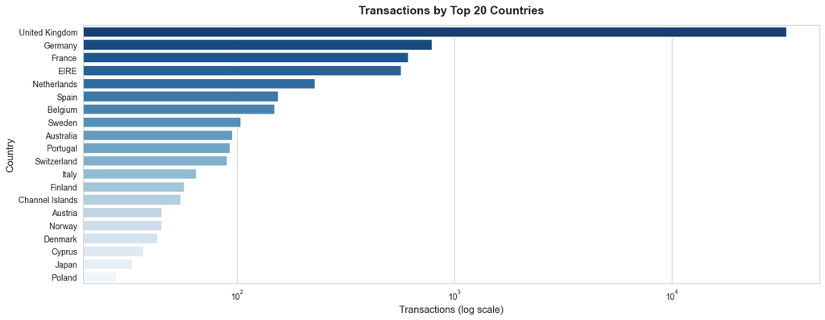

```python
def plot_transactions_by_country():
    sns.set_style("whitegrid")
    fig, ax = plt.subplots(figsize=(14, 5.5))
    transactions_by_country = df.groupby("Country", observed=True)["Invoice"].nunique().sort_values(ascending=False).head(20)
    sns.barplot(
        x=transactions_by_country.values,
        y=transactions_by_country.index.astype(str),
        hue=transactions_by_country.index.values,
        palette="Blues_r"
    )
    ax.tick_params(axis='x', rotation=0)
    ax.set_title("Transactions by Top 20 Countries", fontsize=14, fontweight="bold", pad=14)
    ax.set_xlabel("Transactions (log scale)", fontsize=12)
    ax.set_ylabel("Country", fontsize=12)
    ax.set_xscale("log")
    plt.tight_layout()
    plt.show()
plot_transactions_by_country()
```

The top-selling products exhibit a moderately skewed distribution, with the two most popular products standing out from the rest. However, the remaining top-selling items also record substantial sales volumes, indicating that customer demand is distributed across a variety of products rather than being dominated by a single bestseller.

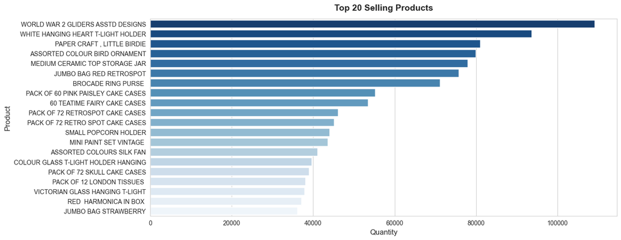

```python
def plot_top_selling_products():
    sns.set_style("whitegrid")
    fig, ax = plt.subplots(figsize=(14, 5.5))
    top_selling_products = df.groupby("Description", observed=True)["Quantity"].sum().sort_values(ascending=False).head(20)
    sns.barplot(
        x=top_selling_products.values,
        y=top_selling_products.index.astype(str),
        hue=top_selling_products.index.values,
        palette="Blues_r"
    )
    ax.tick_params(axis='x', rotation=0)
    ax.set_title("Top 20 Selling Products", fontsize=14, fontweight="bold", pad=14)
    ax.set_xlabel("Quantity", fontsize=12)
    ax.set_ylabel("Product", fontsize=12)
    plt.tight_layout()
    plt.show()
plot_top_selling_products()
```

The monthly sales exhibit a clear seasonal pattern across the period observed. Following a decline that reaches its lowest level in February, sales recover in March and remain relatively stable throughout the spring and summer months. Beginning in August, sales increase steadily, culminating in a pronounced peak during November. This is followed by a sharp decline in December, likely reflecting the completion of the holiday shopping season and the fact that the dataset contains only part of December 2011. Overall, the similarity between the yearly trends suggests a consistent seasonal purchasing pattern.

The apparent decline in sales in December should be interpreted with caution, as the data for December 2011 is incomplete.

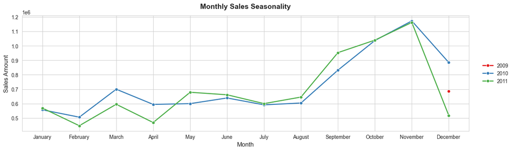

```python
def plot_monthly_sales():
    sns.set_style("whitegrid")
    fig, ax = plt.subplots(figsize=(14, 4.2))
    df_aux = df.copy()
    df_aux["Month"] = df_aux["InvoiceDate"].dt.month
    df_aux["Year"] = df_aux["InvoiceDate"].dt.year
    monthly_sales = df_aux.groupby(["Year", "Month"], observed=True)["TotalPrice"].sum().reset_index()
    sns.lineplot(
        data=monthly_sales,
        x="Month",
        y="TotalPrice",
        hue="Year",
        marker="o",
        linewidth=2,
        palette="Set1",
        ax=ax
    )
    ax.tick_params(axis='x', rotation=0)
    ax.set_xticks(range(1, 13))
    ax.set_xticklabels(calendar.month_name[1:])
    ax.set_title("Monthly Sales Seasonality", fontsize=14, fontweight="bold", pad=14)
    ax.set_xlabel("Month", fontsize=12)
    ax.set_ylabel("Sales Amount", fontsize=12)
    ax.legend(loc="center left", bbox_to_anchor=(1.02, 0.5), frameon=False )
    plt.tight_layout()
    plt.show()
plot_monthly_sales()
```

The distribution of order amounts is highly concentrated in the lowest value intervals, with the order value increasing as the number of orders decreases progressively. This indicates that most purchases correspond to relatively low-value orders, while high-value purchases occur much less frequently. A small number of exceptionally expensive orders appear as isolated outliers, reflecting the presence of customers with unusually high spending levels.

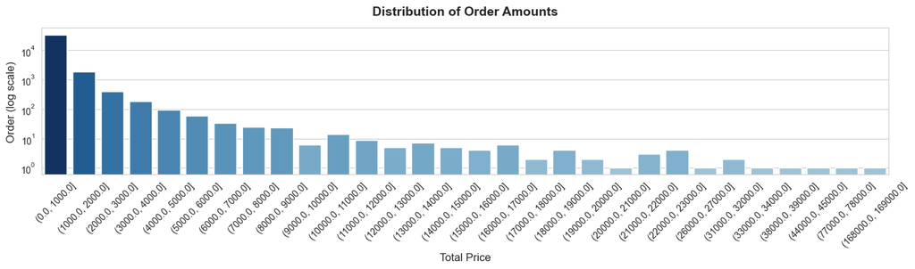

```python
def plot_total_price_distribution():
    sns.set_style("whitegrid")
    fig, ax = plt.subplots(figsize=(14, 4.2))
    df_aux = df.copy()
    total_price_distribution = df_aux.groupby("Invoice", observed=True).agg( TotalPrice=("TotalPrice", "sum") )
    total_price_distribution["TotalPrice_Bucket"] = pd.cut(total_price_distribution["TotalPrice"], bins=np.linspace(0, 200000, 201))
    total_price_distribution = total_price_distribution.groupby("TotalPrice_Bucket", observed=True).size()
    log_values = np.log10(total_price_distribution.values)
    norm = plt.Normalize( log_values.min(), log_values.max() )
    sns.barplot(
        x=total_price_distribution.index.astype(str),
        y=total_price_distribution.values,
        hue=total_price_distribution.index.astype(str),
        palette=plt.cm.Blues(0.4 + 0.6 * norm(log_values)).tolist()
    )
    ax.tick_params(axis='x', rotation=45)
    ax.set_title("Distribution of Order Amounts", fontsize=14, fontweight="bold", pad=14)
    ax.set_xlabel("Total Price", fontsize=12)
    ax.set_ylabel("Order (log scale)", fontsize=12)
    ax.set_yscale("log")
    plt.tight_layout()
    plt.show()
plot_total_price_distribution()
```

The distribution of item quantities is highly concentrated in the smallest quantity interval, with the number of purchased items decreasing rapidly as the quantity increases. This indicates that most products are purchased in relatively small quantities, while bulk purchases are uncommon and appear only as isolated cases.

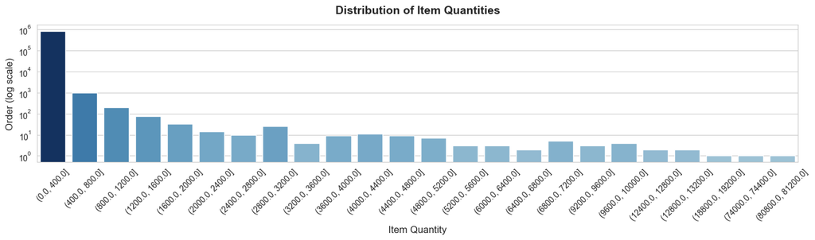

```python
def plot_item_quantity_distribution():
    sns.set_style("whitegrid")
    fig, ax = plt.subplots(figsize=(14, 4.2))
    df_aux = df.copy()
    df_aux["Quantity_Bucket"] = pd.cut(df_aux["Quantity"], bins=np.linspace(0, 100000, 251))
    item_quantity_distribution = df_aux.groupby("Quantity_Bucket", observed=True)["Invoice"].size()
    log_values = np.log10(item_quantity_distribution.values)
    norm = plt.Normalize( log_values.min(), log_values.max() )
    sns.barplot(
        x=item_quantity_distribution.index.astype(str),
        y=item_quantity_distribution.values,
        hue=item_quantity_distribution.index.astype(str),
        palette=plt.cm.Blues(0.4 + 0.6 * norm(log_values)).tolist()
    )
    ax.tick_params(axis='x', rotation=45)
    ax.set_title("Distribution of Item Quantities", fontsize=14, fontweight="bold", pad=14)
    ax.set_xlabel("Item Quantity", fontsize=12)
    ax.set_ylabel("Order (log scale)", fontsize=12)
    ax.set_yscale("log")
    plt.tight_layout()
    plt.show()
plot_item_quantity_distribution()
```

The distribution of spending among the top 20 customers is highly skewed, with two customers clearly outperforming the rest by spending more than 500,000 monetary units during the study period. This observation provides an early indication that meaningful customer segments may exist, a hypothesis that is formally investigated through RFM analysis and K-Means clustering in the following sections.

The top 20 customers account for 21,8% of the retailer's total revenue, highlighting the disproportionate contribution of a relatively small group of customers to overall sales.

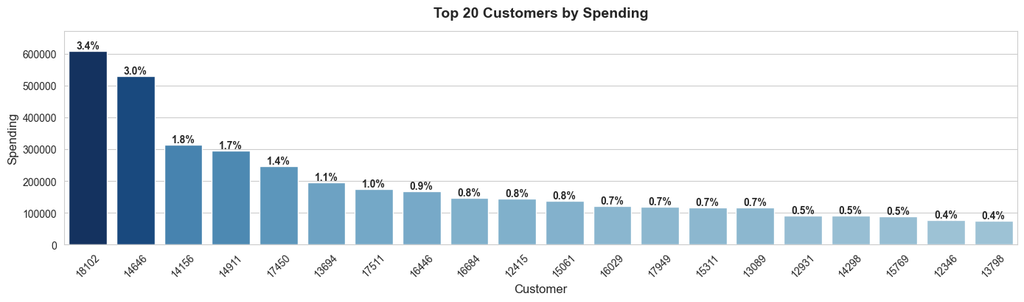

```python
def plot_top_customers_by_spending():
    sns.set_style("whitegrid")
    fig, ax = plt.subplots(figsize=(14, 4.2))
    df_aux = df.copy()
    df_aux["TotalPrice"] = df_aux["Quantity"] * df_aux["Price"]
    customer_spending = df_aux.groupby("CustomerID", observed=True)["TotalPrice"].sum().sort_values(ascending=False)
    top_customers_by_spending = customer_spending.head(20)
    top_customer_spending_pct = ( (100 * ( customer_spending / customer_spending.sum() ) ).round(2) )[:20]
    values = top_customers_by_spending.values
    norm = plt.Normalize( values.min(), values.max() )
    sns.barplot(
        x=top_customers_by_spending.index.astype(str),
        y=top_customers_by_spending.values,
        hue=top_customers_by_spending.index.astype(str),
        palette=plt.cm.Blues(0.4 + 0.6 * norm(values)).tolist()
    )

    for bar, pct in zip(ax.patches, top_customer_spending_pct):
        ax.text(
            bar.get_x() + bar.get_width() / 2,
            bar.get_height(),
            f"{pct:.1f}%",
            ha="center",
            va="bottom",
            fontsize=10,
            fontweight="bold"
        )
    ax.tick_params(axis='x', rotation=45)
    ax.set_title("Top 20 Customers by Spending", fontsize=14, fontweight="bold", pad=14)
    ax.set_xlabel("Customer", fontsize=12)
    ax.set_ylabel("Spending", fontsize=12)
    ax.set_ylim(0, top_customers_by_spending.values.max() * 1.1)
    plt.tight_layout()
    plt.show()
plot_top_customers_by_spending()
```

The distribution of the top 20 customers by order volume is highly skewed, with two customers clearly standing out by placing more than 325 orders during the observation period. This variation in purchasing behavior further supports the use of RFM analysis to identify distinct customer segments based on recency, purchase frequency, and monetary value.

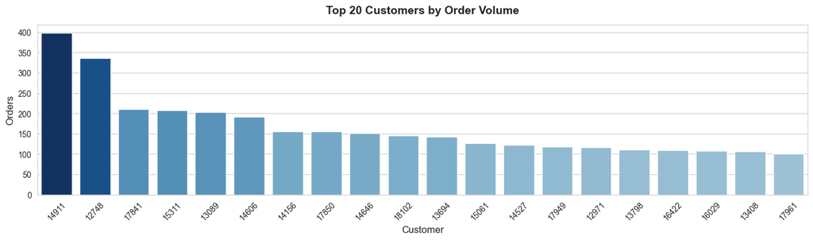

```python
def plot_orders_per_customer():
    sns.set_style("whitegrid")
    fig, ax = plt.subplots(figsize=(14, 4.2))
    top_customers_by_order_volume = df.groupby("CustomerID", observed=True)["Invoice"].nunique().sort_values(ascending=False).head(20)
    values = top_customers_by_order_volume.values
    norm = plt.Normalize( values.min(), values.max() )
    sns.barplot(
        x=top_customers_by_order_volume.index.astype(str),
        y=top_customers_by_order_volume.values,
        hue=top_customers_by_order_volume.index.astype(str),
        palette=plt.cm.Blues(0.4 + 0.6 * norm(values)).tolist()
    )
    ax.tick_params(axis='x', rotation=45)
    ax.set_title("Top 20 Customers by Order Volume", fontsize=14, fontweight="bold", pad=14)
    ax.set_xlabel("Customer", fontsize=12)
    ax.set_ylabel("Orders", fontsize=12)
    plt.tight_layout()
    plt.show()
plot_orders_per_customer()
```

Unlike the ranking based on total spending, the customers with the highest order volumes are not necessarily those who generate the greatest revenue. This difference indicates that customers exhibit distinct purchasing behaviors: some place frequent but relatively small orders, while others make fewer purchases with substantially higher order values. Consequently, evaluating customer behavior requires considering both purchase frequency and monetary contribution, motivating the use of the RFM framework in the next section.

# Feature Engineering

In this section, the Recency, Frequency, and Monetary (RFM) features are constructed to characterize each customer's purchasing behavior. These features form the basis of the subsequent customer segmentation analysis.

Recency is computed as the number of days between the snapshot date (defined as one day after the most recent transaction in the dataset) and the customer's last recorded purchase. This feature measures how recently each customer made a purchase.

Frequency is computed as the number of unique invoices associated with each customer, representing the total number of purchase orders placed during the observation period.

Monetary is computed as the cumulative amount spent by each customer, obtained by summing the TotalPrice of all transactions associated with that customer throughout the study period.

After constructing the RFM features, the resulting dataset was inspected for missing values to ensure its completeness before proceeding with the clustering analysis.

```python
last_date_observed = df["InvoiceDate"].max() + pd.Timedelta(days=1)
rfm = df.groupby("CustomerID").agg(
    Recency=("InvoiceDate", lambda x: (last_date_observed - x.max()).days),
    Frequency=("Invoice", "nunique"),
    Monetary=("TotalPrice", "sum")
)
rfm.isna().sum().to_frame(name="Count")
```

|  | Count |
| --- | --- |
| Recency | 0 |
| Frequency | 0 |
| Monetary | 0 |

Together, these three features capture complementary aspects of customer behavior by describing how recently customers purchased, how frequently they purchase, and how much they spend. This compact representation provides an effective basis for identifying groups of customers with similar purchasing patterns.

# Exploratory Analysis of RFM Features

The table below presents the summary statistics of the RFM features. These statistics provide an overview of the distribution of customer recency, purchase frequency, and monetary value before the application of feature scaling and clustering.

```python
rfm.describe()
```

|  | Recency | Frequency | Monetary |
| --- | --- | --- | --- |
| count | 5878.000000 | 5878.000000 | 5878.000000 |
| mean | 201.331916 | 6.289384 | 3018.616737 |
| std | 209.338707 | 13.009406 | 14737.731040 |
| min | 1.000000 | 1.000000 | 2.950000 |
| 25% | 26.000000 | 1.000000 | 348.762500 |
| 50% | 96.000000 | 3.000000 | 898.915000 |
| 75% | 380.000000 | 7.000000 | 2307.090000 |
| max | 739.000000 | 398.000000 | 608821.650000 |

The skewness coefficients in the following table indicate that all three RFM features exhibit positively skewed distributions. While Recency is moderately skewed, Frequency and Monetary display pronounced positive skewness, reflecting the presence of a small number of customers with exceptionally high purchase frequencies and spending levels. These observations are consistent with the patterns identified during the exploratory data analysis and further motivate the application of feature scaling prior to clustering.

```python
rfm.skew(numeric_only=True).to_frame(name="Values")
```

|  | Values |
| --- | --- |
| Recency | 0.887198 |
| Frequency | 12.639951 |
| Monetary | 25.314235 |

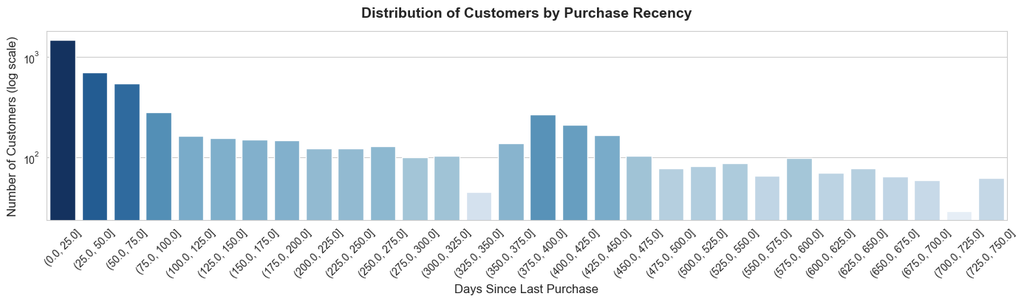

```python
def plot_recency_distribution():
    sns.set_style("whitegrid")
    fig, ax = plt.subplots(figsize=(14, 4.2))
    df_aux = rfm.copy()
    max_value = int(df_aux["Recency"].max())
    high_limit = (10 ** math.floor(math.log10( max_value ))) * math.ceil( max_value / (10 ** math.floor(math.log10( max_value ))))
    df_aux["Recency_Bucket"] = pd.cut(df_aux["Recency"], bins=np.linspace(0, high_limit, int(high_limit / 25) + 1))
    recency_distribution = df_aux.groupby("Recency_Bucket", observed=True).size()
    log_values = np.log10(recency_distribution.values)
    norm = plt.Normalize( log_values.min(), log_values.max() )
    sns.barplot(
        x=recency_distribution.index.astype(str),
        y=recency_distribution.values,
        hue=recency_distribution.index.astype(str),
        palette=plt.cm.Blues(0.1 + 0.9 * norm(log_values)).tolist()
    )
    ax.tick_params(axis='x', rotation=45)
    ax.set_title("Distribution of Customers by Purchase Recency", fontsize=14, fontweight="bold", pad=14)
    ax.set_xlabel("Days Since Last Purchase", fontsize=12)
    ax.set_ylabel("Number of Customers (log scale)", fontsize=12)
    ax.set_yscale("log")
    plt.tight_layout()
    plt.show()
plot_recency_distribution()
```

The distribution of customer purchase frequency is highly positively skewed. While the majority of customers made only a few purchases during the study period, a small number of customers placed orders much more frequently, representing the retailer's most active customers. This considerable variability in purchasing frequency is an important characteristic for distinguishing customer segments within the RFM framework.

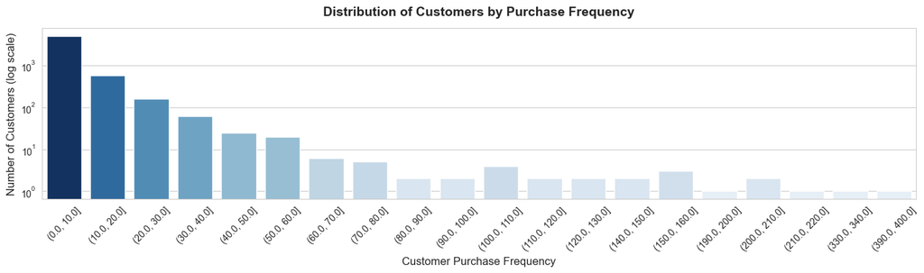

```python
def plot_frequency_distribution():
    sns.set_style("whitegrid")
    fig, ax = plt.subplots(figsize=(14, 4.2))
    df_aux = rfm.copy()
    max_value = int(df_aux["Frequency"].max())
    high_limit = (10 ** math.floor(math.log10( max_value ))) * math.ceil( max_value / (10 ** math.floor(math.log10( max_value ))))
    df_aux["Frequency_Bucket"] = pd.cut(df_aux["Frequency"], bins=np.linspace(0, high_limit, int(high_limit / 10) + 1))
    frequency_distribution = df_aux.groupby("Frequency_Bucket", observed=True).size()
    log_values = np.log10(frequency_distribution.values)
    norm = plt.Normalize( log_values.min(), log_values.max() )
    sns.barplot(
        x=frequency_distribution.index.astype(str),
        y=frequency_distribution.values,
        hue=frequency_distribution.index.astype(str),
        palette=plt.cm.Blues(0.1 + 0.9 * norm(log_values)).tolist()
    )
    ax.tick_params(axis='x', rotation=45)
    ax.set_title("Distribution of Customers by Purchase Frequency", fontsize=14, fontweight="bold", pad=14)
    ax.set_xlabel("Customer Purchase Frequency", fontsize=12)
    ax.set_ylabel("Number of Customers (log scale)", fontsize=12)
    ax.set_yscale("log")
    plt.tight_layout()
    plt.show()
plot_frequency_distribution()
```

The distribution of customer monetary value exhibits an extremely positively skewed distribution. Most customers contributed relatively modest amounts to the retailer's revenue, whereas a very small number of customers spent exceptionally large amounts. This wide variation in customer spending makes the Monetary feature an essential component for identifying customers with different economic value.

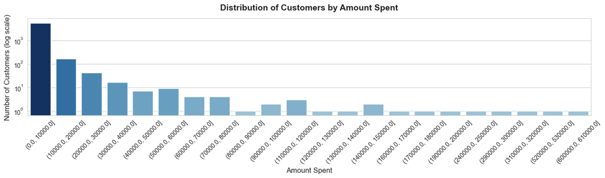

```python
def plot_monetary_distribution():
    sns.set_style("whitegrid")
    fig, ax = plt.subplots(figsize=(14, 4.2))
    df_aux = rfm.copy()
    max_value = int(df_aux["Monetary"].max())
    high_limit = (10 ** math.floor(math.log10( max_value ))) * math.ceil( max_value / (10 ** math.floor(math.log10( max_value ))))
    df_aux["Monetary_Bucket"] = pd.cut(df_aux["Monetary"], bins=np.linspace(0, high_limit, int(high_limit / 10000) + 1))
    monetary_distribution = df_aux.groupby("Monetary_Bucket", observed=True).size()
    log_values = np.log10(monetary_distribution.values)
    norm = plt.Normalize( log_values.min(), log_values.max() )
    sns.barplot(
        x=monetary_distribution.index.astype(str),
        y=monetary_distribution.values,
        hue=monetary_distribution.index.astype(str),
        palette=plt.cm.Blues(0.4 + 0.6 * norm(log_values)).tolist()
    )
    ax.tick_params(axis='x', rotation=45)
    ax.set_title("Distribution of Customers by Amount Spent", fontsize=14, fontweight="bold", pad=14)
    ax.set_xlabel("Amount Spent", fontsize=12)
    ax.set_ylabel("Number of Customers (log scale)", fontsize=12)
    ax.set_yscale("log")
    plt.tight_layout()
    plt.show()
plot_monetary_distribution()
```

To provide a more comprehensive assessment of the relationships among the RFM features, three correlation measures were computed. Pearson evaluates linear associations, Spearman evaluates monotonic relationships based on ranked observations, and PhiK is capable of capturing more general nonlinear dependencies.

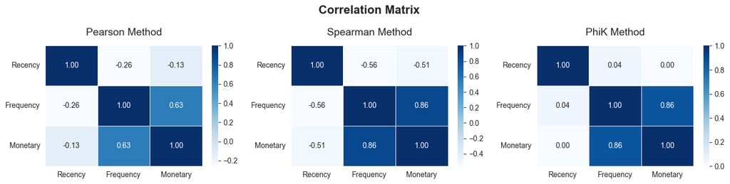

```python
def plot_feature_correlation(data):
    cols = data.columns
    corr_phik = data[cols].phik_matrix(interval_cols=cols)
    corr_pearson = data[cols].corr()
    corr_spearman = data[cols].corr(method="spearman")
    datalen = len(corr_phik)

    sns.set_style("whitegrid")
    fig, axes = plt.subplots(1, 3, figsize=(14, 3.5))
    fig.suptitle( "Correlation Matrix", y=0.98, fontsize=16, fontweight="bold" )
    sns.heatmap(
        data=corr_pearson,
        annot=True,
        cmap="Blues",
        fmt=".2f",
        ax=axes[0],
        annot_kws={"size": 10},
        linewidths=0.5
    )
    axes[0].tick_params(axis='y', rotation=0)
    axes[0].set_title("Pearson Method", fontsize=14, pad=14)
    sns.heatmap(
        data=corr_spearman,
        annot=True,
        cmap="Blues",
        fmt=".2f",
        ax=axes[1],
        annot_kws={"size": 10},
        linewidths=0.5
    )
    axes[1].tick_params(axis='y', rotation=0)
    axes[1].set_title("Spearman Method", fontsize=14, pad=14)
    sns.heatmap(
        data=corr_phik,
        annot=True,
        cmap="Blues",
        fmt=".2f",
        ax=axes[2],
        annot_kws={"size": 10},
        linewidths=0.5
    )
    axes[2].tick_params(axis='y', rotation=0)
    axes[2].set_title("PhiK Method", fontsize=14, pad=14)
    plt.tight_layout()
    plt.show()
plot_feature_correlation(rfm)
```

# Feature Scaling

The RFM features exhibit substantially different numerical ranges and distributions. In particular, Monetary values are several orders of magnitude larger than Frequency and Recency. Since the K-Means algorithm relies on Euclidean distances to assign observations to clusters, features with larger numerical scales would disproportionately influence the clustering results. Therefore, the RFM features were standardized using the StandardScaler transformation, centering each feature at a mean of zero and scaling it to a unit standard deviation. This transformation was performed prior to model training to ensure that all RFM features contributed equally to the distance calculations. The resulting standardized dataset was subsequently used for determining the optimal number of clusters and fit the K-Means model.

```python
scaler = StandardScaler()
rfm_scaled = scaler.fit_transform(rfm)
pd.DataFrame( rfm_scaled[:10], columns=rfm.columns ).T
```

|  | 0 | 1 | 2 | 3 | 4 | 5 | 6 | 7 | 8 | 9 |
| --- | --- | --- | --- | --- | --- | --- | --- | --- | --- | --- |
| Recency | 0.595584 | -0.952279 | -0.603532 | -0.871064 | 0.519146 | 0.829674 | -0.789849 | 0.012746 | 0.146512 | 0.060520 |
| Frequency | 0.438998 | 0.131502 | -0.099120 | -0.175994 | -0.406616 | -0.406616 | 0.285250 | -0.329742 | -0.406616 | -0.329742 |
| Monetary | 5.058050 | 0.177431 | -0.067806 | 0.095686 | -0.182148 | -0.184419 | -0.011453 | -0.177238 | -0.131593 | -0.140536 |

# Determining the Optimal Number of Clusters

The next step consists of determining the optimal number of customer clusters for the K-Means algorithm. Four complementary evaluation techniques were employed:

- The Elbow Method, which assesses the reduction in within-cluster variance as the number of clusters increases.
- The Silhouette Score method, which measures the degree of separation and cohesion among the resulting clusters and tends to favor solutions where clusters are both compact and well separated.
- The Calinski-Harabasz method,which is based on the ratio of between-cluster to within-cluster variance, and it often increases as the number of clusters increases, so it has a tendency to prefer larger numbers of clusters.
- The Davies-Bouldin method, which measures the average similarity between each cluster and its most similar neighboring cluster. Lower values are better, but it can also favor slightly larger numbers of clusters.

The Elbow Method indicated a point of diminishing returns at k = 4, while the Silhouette Score achieved its highest value (0.591) for the same number of clusters.

Although the Calinski-Harabasz and Davies-Bouldin indices favored solutions with a larger number of clusters, both the Elbow Method and the Silhouette Score consistently identified k = 4 as the most appropriate choice. Since the Silhouette Score directly evaluates both cluster cohesion and separation, and the Elbow Method indicated diminishing improvements beyond four clusters, four clusters were selected for the final K-Means model. The agreement between the two evaluation techniques provides additional confidence that the selected number of clusters achieves a suitable balance between cluster compactness and separation.

```python
def compute_k_inertia_silhouette_calinski_davies_score(data):
    results = []
    for k in range(2, 11):
        kmeans = KMeans( n_clusters=k, random_state=42 )
        clusters = kmeans.fit_predict(data)
        results.append({
            "k" : k,
            "Elbow" : kmeans.inertia_,
            "SilhouetteScore" : silhouette_score(data, clusters),
            "Calinski-Harabasz" : calinski_harabasz_score(data, clusters),
            "Davies-Bouldin" : davies_bouldin_score(data, clusters)
        })
    return pd.DataFrame(results)
optimal_number_of_clusters = compute_k_inertia_silhouette_calinski_davies_score(rfm_scaled)
optimal_number_of_clusters.style.hide(axis="index")
```

| k | Elbow | SilhouetteScore | Calinski-Harabasz | Davies-Bouldin |
| --- | --- | --- | --- | --- |
| 2 | 12532.270124 | 0.556480 | 2392.069462 | 0.664813 |
| 3 | 7124.406815 | 0.580363 | 4333.281518 | 0.634716 |
| 4 | 5166.451481 | 0.590524 | 4724.996434 | 0.641363 |
| 5 | 4517.729348 | 0.495221 | 4262.810929 | 0.666706 |
| 6 | 3421.486544 | 0.544027 | 4878.359603 | 0.613466 |
| 7 | 2737.046004 | 0.549374 | 5325.694002 | 0.715149 |
| 8 | 2307.201509 | 0.548889 | 5570.803288 | 0.680773 |
| 9 | 2005.631964 | 0.480807 | 5716.700934 | 0.719923 |
| 10 | 1758.159635 | 0.497235 | 5887.701759 | 0.686315 |

The Elbow Method plot below shows a pronounced reduction in inertia as the number of clusters increases from two to four, after which the rate of reduction decreases substantially. This behavior indicates diminishing returns from adding additional clusters. Consistently, the Silhouette Score reaches its maximum value at k = 4. Increasing the number of clusters beyond four does not improve the clustering quality. On the contrary, the Silhouette Score decreases noticeably, indicating that additional clusters produce less cohesive and less well-separated customer groups.

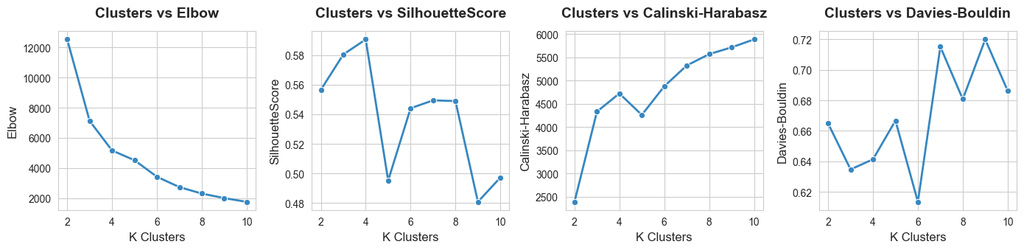

```python
def k_vs_elbow_vs_silhouettescore_vs_calinski_vs_davies(data):
    sns.set_style("whitegrid")
    fig, axes = plt.subplots(1, 4, figsize=(14, 3.5))
    for i in range(len(data.columns) - 1):
        sns.lineplot(
            x=data.k,
            y=data[data.columns[i + 1]],
            marker="o",
            linewidth=2,
            color=sns.color_palette("Blues", n_colors=5)[3],
            ax=axes[i]
        )
        axes[i].tick_params(axis='x', rotation=0)
        axes[i].set_title(f"Clusters vs {data.columns[i + 1]}", fontsize=14, fontweight="bold", pad=14)
        axes[i].set_xlabel("K Clusters", fontsize=12)
        axes[i].set_ylabel(f"{data.columns[i + 1]}", fontsize=12)
    plt.tight_layout()
    plt.show()
k_vs_elbow_vs_silhouettescore_vs_calinski_vs_davies(optimal_number_of_clusters)
```

# Model Training Using K-Means

After determining the optimal number of clusters, the K-Means algorithm was trained using the standardized RFM features with k = 4. The algorithm partitions customers into groups by minimizing the within-cluster variance, thereby identifying customers with similar purchasing behaviors based on their recency, purchase frequency, and monetary value. The resulting cluster labels were assigned to each customer in the RFM dataset, enabling the subsequent analysis and profiling of the identified customer segments.

```python
kmeans = KMeans( n_clusters=optimal_number_of_clusters["k"].iloc[optimal_number_of_clusters["SilhouetteScore"].argmax()], random_state=42 )
rfm["Cluster"] = kmeans.fit_predict(rfm_scaled)
```

# Cluster Analysis and Profiling

After training the K-Means model, the identified customer clusters were profiled by computing the mean values of the Recency, Frequency, and Monetary features, together with the number of customers assigned to each cluster. These summary statistics provide a high-level characterization of the purchasing behavior associated with each customer segment and serve as the basis for assigning business-oriented labels and deriving actionable insights.

```python
cluster_profiles = rfm.groupby("Cluster").agg(
    AvgRecency=("Recency", "mean"),
    AvgFrequency=("Frequency", "mean"),
    AvgMonetary=("Monetary", "mean"),
    Customers=("Recency", "size")
)
cluster_profiles[["AvgRecency", "AvgFrequency", "AvgMonetary"]] = cluster_profiles[["AvgRecency", "AvgFrequency", "AvgMonetary"]].round(2)
cluster_profiles
```

| Cluster | AvgRecency | AvgFrequency | AvgMonetary | Customers |
| --- | --- | --- | --- | --- |
| 0 | 463.03 | 2.21 | 765.24 | 1998 |
| 1 | 67.01 | 7.31 | 3009.40 | 3841 |
| 2 | 25.94 | 103.71 | 83086.08 | 35 |
| 3 | 3.50 | 212.50 | 436835.79 | 4 |

The cluster profiles reveal four distinct customer segments with markedly different purchasing behaviors. Cluster 0 consists of customers with the highest mean recency and the lowest mean purchase frequency and spending, indicating customers who have become inactive or contribute less to the retailer's revenue. Cluster 1 represents the largest customer group and is characterized by moderate recency, purchase frequency, and monetary value, corresponding to the retailer's regular customer base. Clusters 2 and 3 contain progressively smaller groups of customers with increasingly recent purchases, substantially higher purchase frequencies, and considerably greater spending, representing the retailer's high-value customer segments.

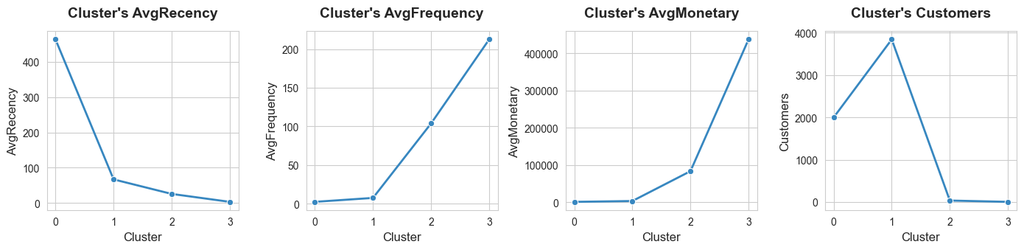

```python
def plot_cluster_vs_features():
    sns.set_style("whitegrid")
    fig, axes = plt.subplots(1, 4, figsize=(14, 3.5))

    for i in range(len(cluster_profiles.columns)):
        sns.lineplot(
            x=cluster_profiles.index,
            y=cluster_profiles[cluster_profiles.columns[i]],
            marker="o",
            linewidth=2,
            color=sns.color_palette("Blues", n_colors=5)[3],
            ax=axes[i]
        )
        axes[i].tick_params(axis='x', rotation=0)
        axes[i].set_title(f"Cluster's {cluster_profiles.columns[i]}", fontsize=14, fontweight="bold", pad=14)
        axes[i].set_xlabel("Cluster", fontsize=12)
        axes[i].set_ylabel(f"{cluster_profiles.columns[i]}", fontsize=12)

    plt.tight_layout()
    plt.show()
plot_cluster_vs_features()
```

To facilitate the interpretation of the clustering results, a new feature named CustomerSegment was added to the cluster profile. Based on the average Recency, Frequency, and Monetary values of each cluster, descriptive business labels were assigned to the identified customer segments: At-Risk Customers, Base Customers, High-Value Customers, and VIP Customers. These labels provide an intuitive interpretation of the customer groups while preserving the underlying cluster assignments produced by the K-Means algorithm..

```python
cluster_profiles["CustomerSegment"] = ["At-Risk Customers", "Base Customers", "High-Value Customers", "VIP Customers"]
```

Based on the identified customer segments, the following business actions may be considered:

- At-Risk Customers: Launch re-engagement campaigns and offer personalized discounts to encourage customers to return.
- Base Customers: Maintain engagement through loyalty programs and personalized recommendations.
- High-Value Customers: Strengthen customer relationships by offering exclusive benefits, rewards, and early access to new products.
- VIP Customers: Provide premium services, dedicated account management, and highly personalized experiences to maximize long-term retention.

The following table presents a cluster summary consisting of cluster profile along with the corresponding business actions.

```python
cluster_summary = cluster_profiles.copy()
cluster_summary["Recommendation"] = ["Launch re-engagement campaigns and offer personalized discounts to encourage customers to return.", "Maintain engagement through loyalty programs and personalized recommendations.", "Strengthen customer relationships by offering exclusive benefits, rewards, and early access to new products.", "Provide premium services, dedicated account management, and highly personalized experiences to maximize long-term retention."]
cluster_summary
```

| Cluster | AvgRecency | AvgFrequency | AvgMonetary | Customers | CustomerSegment | Recommendation |
| --- | --- | --- | --- | --- | --- | --- |
| 0 | 463.03 | 2.21 | 765.24 | 1998 | At-Risk Customers | Launch re-engagement campaigns and offer personalized discounts to encourage customers to return. |
| 1 | 67.01 | 7.31 | 3009.40 | 3841 | Base Customers | Maintain engagement through loyalty programs and personalized recommendations. |
| 2 | 25.94 | 103.71 | 83086.08 | 35 | High-Value Customers | Strengthen customer relationships by offering exclusive benefits, rewards, and early access to new products. |
| 3 | 3.50 | 212.50 | 436835.79 | 4 | VIP Customers | Provide premium services, dedicated account management, and highly personalized experiences to maximize long-term retention. |

The customer segments and corresponding business actions presented in this study should be interpreted as analytical insights derived from the observed dataset. Since K-Means is an unsupervised learning algorithm, the optimal number of clusters and their characteristics may vary as customer purchasing behavior evolves over time. Consequently, the assigned business labels and recommended actions are intended for exploratory analysis rather than as fixed rules for deployment in a production environment.

# Cluster Visualization Using PCA (Principal Component Analysis)

Principal Component Analysis (PCA) was applied to reduce the three-dimensional RFM feature space to two principal components. This transformation was performed solely for visualization purposes, enabling the customer segments identified by K-Means to be displayed in a two-dimensional scatter plot while preserving most of the variability present in the original RFM feature space. The first two principal components explain approximately 88.15% of the total variance, indicating that the two-dimensional projection preserves most of the information contained in the original RFM features. This makes the PCA scatter plot a meaningful representation of the customer segmentation results.

```python
pca = PCA(n_components=2, random_state=42)
rfm_pca = pca.fit_transform(rfm_scaled)
rfm["PC1"] = rfm_pca[:, 0]
rfm["PC2"] = rfm_pca[:, 1]
pd.DataFrame((pca.explained_variance_ratio_ * 100).round(2).tolist(), columns=["Value"], index=["PC1", "PC2"]).T
```

|  | PC1 | PC2 |
| --- | --- | --- |
| Value | 57.68 | 30.47 |

The PCA projection provides a clear visual representation of the customer segments identified by the K-Means algorithm. The VIP Customers form a well-isolated cluster, reflecting their distinctive purchasing behavior and exceptionally high RFM values. The High-Value Customers also appear clearly separated from the remaining customer segments, with minimal overlap. Although a small number of Base and At-Risk Customers are located slightly farther from the main concentration of their respective groups, both segments remain compact overall. This visualization suggests that the clustering algorithm successfully identified well-defined customer groups with distinct purchasing characteristics.

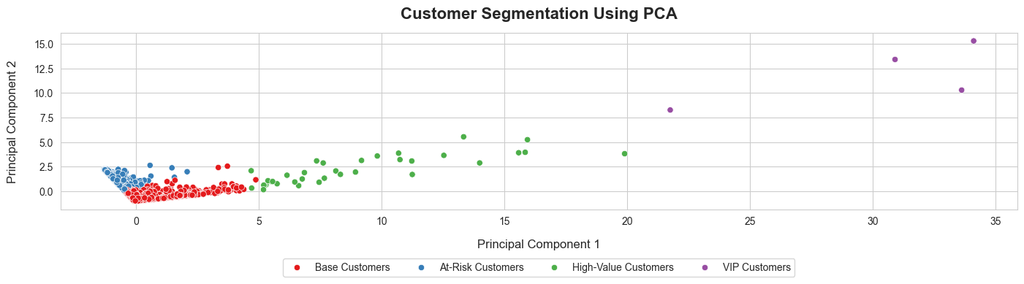

```python
def plot_PCA_components(data):
    data = data.copy()
    data["Cluster"] = data["Cluster"].map(cluster_profiles["CustomerSegment"])
    sns.set_style("whitegrid")
    fig, ax = plt.subplots(figsize=(14, 4.2))
    sns.scatterplot(
        x=data.PC1,
        y=data.PC2,
        hue=data.Cluster,
        palette="Set1",
        #legend=False,
        ax=ax
    )
    ax.tick_params(axis='x', rotation=0)
    ax.tick_params(axis='y')
    ax.set_title("Customer Segmentation Using PCA", fontsize=16, fontweight="bold", pad=14)
    ax.set_xlabel("Principal Component 1", fontsize=12, labelpad=12)
    ax.set_ylabel("Principal Component 2", fontsize=12, labelpad=15)
    ax.legend(loc="upper center", bbox_to_anchor=(0.5, -0.25), ncols=data.Cluster.nunique())
    plt.tight_layout()
    plt.show()
plot_PCA_components(rfm)
```

The following table presents the PCA component loadings, indicating the contribution of each original RFM feature to the principal components. The results show that PC1 is primarily influenced by Frequency and Monetary, representing the overall purchasing intensity of customers, whereas PC2 is driven predominantly by Recency, capturing the temporal dimension of customer purchasing behavior.

```python
loadings = pd.DataFrame( pca.components_, columns=["Recency", "Frequency", "Monetary"], index=["PC1", "PC2"] )
loadings
```

|  | Recency | Frequency | Monetary |
| --- | --- | --- | --- |
| PC1 | -0.349528 | 0.679244 | 0.645336 |
| PC2 | 0.923704 | 0.134516 | 0.358715 |

# Business Insights

The customer segmentation analysis identified four distinct customer segments with markedly different purchasing behaviors. The majority of customers belong to the Base Customers segment, characterized by moderate purchase frequency and spending, representing the retailer's primary customer base. A second large segment consists of At-Risk Customers, who have not purchased for a considerable period and exhibit relatively low purchase frequency and monetary value.

Although High-Value Customers and VIP Customers represent only a small fraction of the customer population, they contribute disproportionately to the retailer's commercial performance through exceptionally high purchase frequency and spending. Their distinctive purchasing patterns were consistently identified by the clustering algorithm and remained clearly separated in the PCA visualization.

Overall, the results demonstrate that the RFM framework combined with K-Means clustering provides an effective approach for identifying customer groups with substantially different purchasing characteristics, enabling data-driven customer segmentation.

# Business Recommendations

The identified customer segments suggest several opportunities for targeted customer relationship strategies:

- At-Risk Customers: Develop re-engagement campaigns, personalized discounts, and reminder communications to encourage customers to return.
- Base Customers: Maintain customer engagement through loyalty programs, personalized product recommendations, and regular promotional campaigns.
- High-Value Customers: Strengthen customer retention by providing exclusive offers, premium rewards, and early access to new products.
- VIP Customers: Offer highly personalized services, dedicated customer support, and exclusive experiences to maximize long-term retention.

Rather than applying uniform marketing strategies across the entire customer base, customer segmentation enables retailers to allocate marketing resources more efficiently by tailoring actions to the characteristics of each customer segment.

# Conclusions

This study presented a customer segmentation workflow using the Online Retail II dataset from the UCI Machine Learning Repository. After data preprocessing and exploratory analysis, Recency, Frequency, and Monetary (RFM) features were engineered to summarize each customer's purchasing behavior. Following feature scaling, the optimal number of clusters was determined using both the Elbow Method and the Silhouette Score, leading to the selection of four customer segments.

The resulting clusters exhibited clear differences in purchasing behavior and were successfully interpreted as meaningful customer segments through business-oriented profiling. Principal Component Analysis provided an effective two-dimensional visualization while preserving approximately 88% of the variance contained in the original RFM feature space.

Overall, the study demonstrates that combining RFM analysis with K-Means clustering offers a practical and interpretable approach for customer segmentation, supporting more informed marketing strategies and customer relationship management.

# Future Work

Several extensions may further improve the analysis:

- Evaluate alternative clustering algorithms, such as Hierarchical Clustering, DBSCAN, or Gaussian Mixture Models, and compare their performance with K-Means.
- Investigate additional customer features beyond the traditional RFM framework, including product preferences, purchasing seasonality, or country-specific purchasing behavior.
- Assess the stability of the identified customer segments by evaluating the clustering results across different time periods and data samples.
- Incorporate demographic or customer profile information, when available, to enrich the segmentation and improve the interpretation of the identified customer groups.
- Perform segmentation periodically using more recent transactional data to monitor changes in customer behavior over time.
- Develop predictive models to estimate customer lifetime value or customer churn probability using the identified customer segments as explanatory variables.